# zero-inflated-poisson-normal-mixture

## The Model and Simulation Data

Recall the zero-inflated Poisson model $\text{ZIPoisson}(p, \lambda)$, namely:
$$\begin{align*}
\mathbb{P}(Y = 0|p, \lambda) &= p + (1 - p) \exp(-\lambda)\\
\mathbb{P}(Y = y|y>0, p, \lambda) &= (1 - p) \frac{\lambda^y \exp(-\lambda)}{y!}.
\end{align*}$$
We can use this distribution to build a regression model as follows:
$$\begin{align*}
Y_i &\sim \text{ZIPoisson}(p_i, \lambda_i)\\
\text{logit}(p_i) &= \alpha_p + \beta_p W_i\\
\log(\lambda_i) &= \alpha_\lambda + \beta_\lambda X_i
\end{align*}$$
where $\text{logit}(p_i) \equiv \log[p_i / (1 - p_i)]$. We can *further* extend this model by adding a normal error term to the equation for $\log(\lambda_i)$. To keep things simple, I’ll remove the covariate $W_i$ and rename parameters to get rid of sub-scripts:
$$\begin{align*}
Y_i &\sim \text{ZIPoisson}(p_i, \lambda_i)\\
\text{logit}(p_i) &= \gamma \\
\log(\lambda_i) &= \alpha + \beta X_i + \sigma U_i\\
U_i &\sim \text{Normal}(0, 1)
\end{align*}$$
Here’s some simulated data from: (1) a plain-vanilla Poisson regression, (2) a normal-Poisson mixture, and (3) a zero-inflated normal-Poisson mixture. Intuitively, zero-inflation should make it *harder* to learn the parameters $(\alpha, \beta, \sigma)$ because it amounts to a kind of censoring. For this reason, I’ll use a larger sample size in the simulation that I did for the normal-Poisson mixture we looked at before:

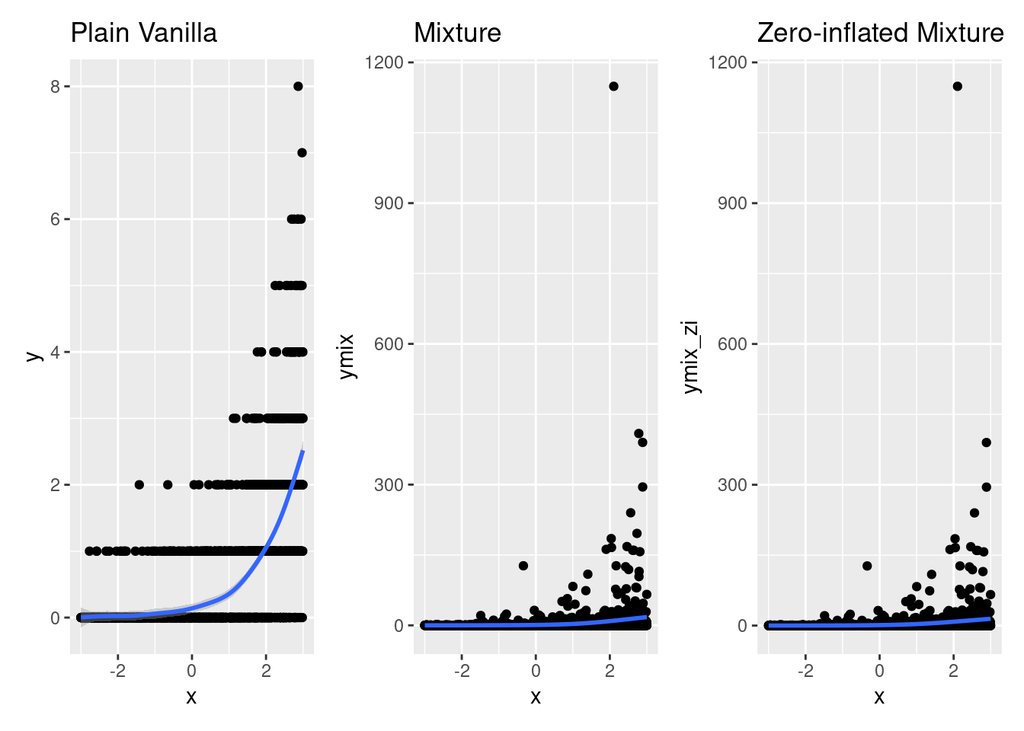

```r
library(rethinking)
library(tidyverse)
library(patchwork)

set.seed(298710)
n <- 2500
a <- -2
b <- 1
s <- 2
p <- 0.1

sim_dat <- tibble(x = runif(n, -3, 3),
                  u = rnorm(n, 0, s),
                  y = rpois(n, exp(a + b * x)),
                  ymix = rpois(n, exp(a + b * x + u)),
                  ymix_zi = ymix * rbinom(n, 1, 1 - p))

dat <- sim_dat |>
  select(x, y, ymix, ymix_zi)

plain <- dat |>
  ggplot(aes(x = x, y = y)) +
  geom_point() +
  geom_smooth() +
  ggtitle('Plain Vanilla')

mix <- dat |>
  ggplot(aes(x = x, y = ymix)) +
  geom_point() +
  geom_smooth() +
  ggtitle('Mixture')

mix_zi <- dat |>
  ggplot(aes(x = x, y = ymix_zi)) +
  geom_point() +
  geom_smooth() +
  ggtitle('Zero-inflated Mixture')

plain + mix + mix_zi
```

## Frequentist Poisson Regression

Recall that the true regression slope and intercept in this simulation are $\alpha=$-2, $\beta=$ 1. Frequentist estimation of the plain-vanilla model should work perfectly, as it does here:

```r
library(broom)
glm(y ~ x, data = dat, family = poisson) |>
  tidy() |>
  knitr::kable(digits = 2)
```

| term | estimate | std.error | statistic | p.value |
| --- | --- | --- | --- | --- |
| (Intercept) | -1.93 | 0.07 | -28.51 | 0 |
| x | 0.97 | 0.03 | 32.22 | 0 |

For the mixture model, Frequenstist estimation of a plain-vanilla Poisson model should be overly-sensitive to extreme values and get the wrong intercept[^1] but still give the right slope in large samples, as it does here:

```r
glm(ymix ~ x, data = dat, family = poisson) |>
  tidy() |>
  knitr::kable(digits = 2)
```

| term | estimate | std.error | statistic | p.value |
| --- | --- | --- | --- | --- |
| (Intercept) | 0.06 | 0.03 | 2.24 | 0.03 |
| x | 1.01 | 0.01 | 91.02 | 0.00 |

```r
glm(ymix_zi ~ x, data = dat, family = poisson) |>
  tidy() |>
  knitr::kable(digits = 2)
```

| term | estimate | std.error | statistic | p.value |
| --- | --- | --- | --- | --- |
| (Intercept) | 0.05 | 0.03 | 1.83 | 0.07 |
| x | 0.96 | 0.01 | 85.25 | 0.00 |

## Bayesian Estimation

Based on my experiments with normal-Poisson mixtures that *do not* feature zero-inflation, I’ve chosen to write the above model in a non-centered form. I’ll use some simple default, weakly informative priors:

```r
d <- dat |>
  rowid_to_column('id') |>  # Calling it i throws a STAN error: it uses i internally
  select(x, y = ymix_zi, id)

zipois_mix <- ulam(
  alist(
    y ~ dzipois(p, lambda),
    logit(p) <- g,
    g ~ dnorm(-1.5, 1),
    log(lambda) <- a + b * x + sigma * u[id],
    u[id] ~ dnorm(0, 1),
    a ~ dnorm(0, 1.5),
    b ~ dnorm(0, 0.2),
    sigma ~ dexp(1)
  ), data = d, chains = 4, cores = 4, cmdstan = TRUE
)
```

[output not shown]

```r
precis(zipois_mix)
```

```
2500 vector or matrix parameters hidden. Use depth=2 to show them.
```

```
            mean         sd      5.5%     94.5%     n_eff    Rhat4
g     -2.2929585 0.55918933 -3.242124 -1.543280  84.93458 1.041858
a     -1.9932489 0.16023579 -2.237552 -1.733051  91.78119 1.036266
b      0.9473568 0.04200388  0.880486  1.015983 249.34783 1.030663
sigma  2.0656513 0.08444756  1.933910  2.199250  93.16214 1.054452
```

Something funny is going on here. The results look basically perfect, but the diagnostics would suggest something is wrong. What gives?

## Footnotes

[^1]: See my normal-Poisson document for details